# HuberMokate_20April2021_InClass

Jane Huber

4/19/2021

## Overview

Minimum Wage is a piece of federal economic policy that sets a floor for wage work in the United States. Originally brought into law during the Great Depression in the 1930’s, the aim was to create “minimum standard of living necessary for health, efficiency and general well-being, without substantially curtailing employment”. [source]

Ever since its creation, there has been vigorous debate across the US political spectrum as to what the value of a minimum wage should be or there should be one at all.

As the “Fight for 15” political movement rises to prominence on the national level, some economists argue that $15/hour simply isn’t ambitious enough or a reflection of the economy as a whole. The Center for Economic and Policy Research (CEPR) claims, “Until 1968, the minimum wage not only kept pace with inflation, it rose in step with productivity growth. The logic is straightforward; we expect that wages in general will rise in step with productivity growth. For workers at the bottom to share in the overall improvement in society’s living standards, the minimum wage should also rise with productivity.” (https://cepr.net/this-is-what-minimum-wage-would-be-if-it-kept-pace-with-productivity/)

The US Bureau of Labor and Statistics (BLS) has tracked two key productivity measurements since 1948—a raw productivity rate (measuring output per hour) and a multifactor productivity rate (measuring output per unit of combined inputs) [https://www.bls.gov/bls/productivity.htm]. We will be using the raw productivity rate since we were able to access cleaned data

The value of inflation of the US dollar is important to factor in because it imbeds purchasing power of the dollar into what the minimum wage includes. For example, a study by Pew Research demonstrates that the minimum wage in 1973, $4.03/hr, has the same purchasing power of $23.68 in August 2018—more than three times the actual minimum wage [https://www.pewresearch.org/fact-tank/2018/08/07/for-most-us-workers-real-wages-have-barely-budged-for-decades/].

Minimum Wage is a piece of federal economic policy that sets a floor for wage work in the United States. Originally brought into law during the Great Depression in the 1930’s, the aim was to create “minimum standard of living necessary for health, efficiency and general well-being, without substantially curtailing employment”.

Ever since its creation, there has been vigorous debate across the US political spectrum as to what the value of a minimum wage should be or there should be one at all.

As the “Fight for 15” political movement rises to prominence on the national level, some economists argue that $15/hour simply isn’t ambitious enough or a reflection of the economy as a whole. The Center for Economic and Policy Research (CEPR) claims, “Until 1968, the minimum wage not only kept pace with inflation, it rose in step with productivity growth. The logic is straightforward; we expect that wages in general will rise in step with productivity growth. For workers at the bottom to share in the overall improvement in society’s living standards, the minimum wage should also rise with productivity.”

This analysis will examine that claim through our own analysis of the numbers, looking to see what the value of the minimum wage would be if, from its inception, minimum wage was increased according to those two variables.

The US Bureau of Labor and Statistics (BLS) has tracked two key productivity measurements since 1948—a raw productivity rate (measuring output per hour) and a multifactor productivity rate (measuring output per unit of combined inputs) . We will be using the raw productivity rate since we were able to access cleaned data.

The value of inflation of the US dollar is important to factor in because it imbeds purchasing power of the dollar into what the minimum wage includes. For example, a study by Pew Research demonstrates that the minimum wage in 1973, $4.03/hr, has the same purchasing power of $23.68 in August 2018—more than three times the actual minimum wage.

Citations: https://cepr.net/this-is-what-minimum-wage-would-be-if-it-kept-pace-with-productivity/ https://www.bls.gov/bls/productivity.htm https://www.pewresearch.org/fact-tank/2018/08/07/for-most-us-workers-real-wages-have-barely-budged-for-decades https://www.forbes.com/advisor/personal-finance/minimum-wage-debate/ https://democracyjournal.org/magazine/29/minimum-wage-catching-up-to-productivity/ https://www.nytimes.com/2020/06/18/business/coronavirus-minimum-wage-increase.html https://www.cnn.com/interactive/2019/business/us-minimum-wage-by-year/index.html

## Questions for classmates

1. Why does our productivity number seem so low?
2. Do you think our calculations look correct for what minimum wage should be, increasing based off of productivity and inflation?
3. Overall thoughts on our project?

## Calculate Values

```r
# Calculate expected minimum wage based off inflation

master_set$ann_inflat <- (master_set$`Annual Inflation`) / 100

master_set$inflat_adj <- vector("numeric", 71)

for (i in seq(nrow(master_set))) {
  if (i == 1) {
    master_set$inflat_adj[i] <- master_set$`Minimum Wage`
  } else {
    master_set$inflat_adj[i] <- (master_set$inflat_adj[i - 1]*master_set$ann_inflat[i]) + master_set$inflat_adj[i-1] }
}

# Calculate expected minimum wage based off inflation
# This means that the minimum wage in 1948 is adjusted solely for inflation annually.
# Does not reflect congress-updated minimum wage values.

master_set_1 <- master_set

master_set_1$ann_inflat <- (master_set_1$`Annual Inflation`) / 100

master_set_1$inflat_adj <- vector("numeric", 71)

for (i in seq(nrow(master_set_1))) {
  if (i == 1) {
    master_set_1$inflat_adj[i] <- master_set_1$`Minimum Wage`
  } else {

    master_set_1$inflat_adj[i] <- master_set_1$inflat_adj[i - 1]* (1 + master_set_1$ann_inflat[i])
    }
}

# Calculate expected minimum wage based off productivity

master_set <- master_set %>%
  mutate(net_prod_change = (`Net Productivity` - lag(`Net Productivity`, default = first(`Net Productivity`))))

master_set <- master_set %>%
  mutate(net_prod_change = (net_prod_change / 100))

master_set$prod_adj <- vector("numeric", 71)

for (i in seq(nrow(master_set))) {
  if (i == 1) {
    master_set$prod_adj[i] <- master_set$`Minimum Wage`
  } else {
    master_set$prod_adj[i] <- (master_set$prod_adj[i - 1]*master_set$net_prod_change[i]) + master_set$prod_adj[i-1]}
}

# This means that the minimum wage in 1948 is adjusted solely for productivity
# increases annually.
# Does not reflect congress-updated minimum wage values.

master_set_1 <-
  master_set_1 %>%
  mutate(net_prod_change = (`Net Productivity` - lag(`Net Productivity`, default = first(`Net Productivity`))))

master_set_1 <-
  master_set_1 %>%
  mutate(net_prod_change = (net_prod_change / 100))

master_set_1$prod_adj <- vector("numeric", 71)

for (i in seq(nrow(master_set_1))) {
  if (i == 1) {
    master_set_1$prod_adj[i] <- master_set_1$`Minimum Wage`
  } else {

    master_set_1$prod_adj[i] <- master_set_1$prod_adj[i - 1]*(1 + master_set_1$net_prod_change[i])
    }

}


# Calculate expected minimum wage based off inflation AND productivity

master_set$net_impact <- master_set$ann_inflat + master_set$net_prod_change

master_set$inflat_prod_adj <- vector("numeric", 71)

for (i in seq(nrow(master_set))) {
  if (i == 1) {
    master_set$inflat_prod_adj[i] <- master_set$`Minimum Wage`
  } else {
    master_set$inflat_prod_adj[i] <- (master_set$inflat_prod_adj[i - 1]*master_set$net_impact[i]) + master_set$inflat_prod_adj[i-1]}
}

master_set <-
  master_set %>%
  select(-c(`Hourly Compensation`, `Annual Inflation`, `Net Productivity`))


# This means that the minimum wage in 1948 is adjusted factoring in both inflation
# and productivity increases annually.
# Does not reflect congress-updated minimum wage values.

master_set_1$net_impact <- master_set_1$ann_inflat + master_set_1$net_prod_change

master_set_1$inflat_prod_adj <- vector("numeric", 71)

for (i in seq(nrow(master_set_1))) {
  if (i == 1) {
    master_set_1$inflat_prod_adj[i] <- master_set_1$`Minimum Wage`
  } else {
    master_set_1$inflat_prod_adj[i] <- (master_set_1$inflat_prod_adj[i - 1]*master_set_1$net_impact[i]) + master_set_1$inflat_prod_adj[i-1]}
}

master_set_1 <-
  master_set_1 %>%
  select(-c(`Hourly Compensation`, `Annual Inflation`, `Net Productivity`))


#Pivot the dataset so that we can compare the following calculated minimum wage
# values:
# (1) Actual minimum wage (Congress)
# (2) Inflation minimum wage
# (3) Productivity minimum wage
# (4) Inflation and productivity minimum wage

master_set_2 <-
  master_set_1 %>%
  pivot_longer(cols = c("Minimum Wage", inflat_adj, prod_adj, inflat_prod_adj),
               names_to = "Type",
               values_to = "Dollars")


#If people want to see more, show in R Studio
master_set_1
```

```
## # A tibble: 71 x 8
##     Year `Minimum Wage` ann_inflat inflat_adj net_prod_change prod_adj
##    <dbl>          <dbl>      <dbl>      <dbl>           <dbl>    <dbl>
##  1  1948           0.4     0.081        0.4            0         0.4
##  2  1949           0.4    -0.012        0.395          0.0155    0.406
##  3  1950           0.75    0.013        0.400          0.0779    0.438
##  4  1951           0.75    0.079        0.432          0.029     0.451
##  5  1952           0.75    0.019        0.440          0.0325    0.465
##  6  1953           0.75    0.008        0.444          0.0392    0.483
##  7  1954           0.75    0.00700      0.447          0.0203    0.493
##  8  1955           0.75   -0.004        0.445          0.0494    0.518
##  9  1956           1       0.015        0.452          0.0021    0.519
## 10  1957           1       0.033        0.467          0.0345    0.537
## # … with 61 more rows, and 2 more variables: net_impact <dbl>,
## #   inflat_prod_adj <dbl>
```

```r
#If people want to see more data, show in R Studio
master_set_2
```

```
## # A tibble: 284 x 6
##     Year ann_inflat net_prod_change net_impact Type            Dollars
##    <dbl>      <dbl>           <dbl>      <dbl> <chr>             <dbl>
##  1  1948      0.081          0         0.081   Minimum Wage      0.4
##  2  1948      0.081          0         0.081   inflat_adj        0.4
##  3  1948      0.081          0         0.081   prod_adj          0.4
##  4  1948      0.081          0         0.081   inflat_prod_adj   0.4
##  5  1949     -0.012          0.0155    0.00350 Minimum Wage      0.4
##  6  1949     -0.012          0.0155    0.00350 inflat_adj        0.395
##  7  1949     -0.012          0.0155    0.00350 prod_adj          0.406
##  8  1949     -0.012          0.0155    0.00350 inflat_prod_adj   0.401
##  9  1950      0.013          0.0779    0.0909  Minimum Wage      0.75
## 10  1950      0.013          0.0779    0.0909  inflat_adj        0.400
## # … with 274 more rows
```

## Graph

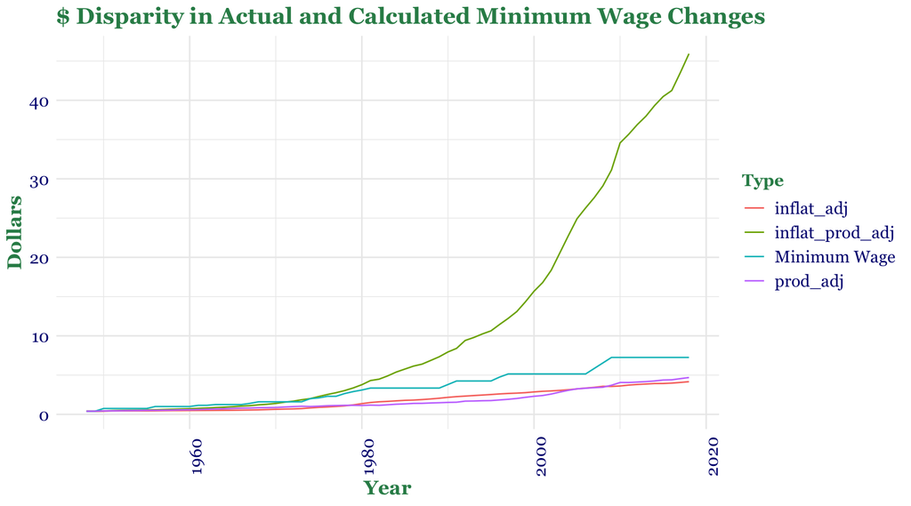

```r
wage_values_graph <-
  master_set_2 %>%
  ggplot() +
  geom_path(aes(x = Year, y=Dollars, color= Type)) +
  labs(title = "$ Disparity in Actual and Calculated Minimum Wage Changes") +
  wage_theme

wage_values_graph
```

## Other Calculations

We also did this, focusing on percent difference rather than raw dollar amounts. Maybe this is right?

```r
master_set_3 <- master_set

master_set_3$increase_act <- vector("numeric", 71)

for (i in seq(nrow(master_set_3))) {
  if (i == 1) {
    master_set_3$increase_act[i] <- 0
  } else {
    master_set_3$increase_act[i] <- ((master_set_3$`Minimum Wage`[i] - master_set_3$`Minimum Wage`[i - 1])/master_set_3$`Minimum Wage`[i - 1])}
}

master_set_3$accum_incr_calc <- vector("numeric", 71)

for (i in seq(nrow(master_set_3))) {
  if (i == 1) {
    master_set_3$accum_incr_calc[i] <- 0
  } else {
    master_set_3$accum_incr_calc[i] <- ((master_set_3$net_impact[i] + master_set_3$accum_incr_calc[i - 1]))}
}

sum(master_set_3$accum_incr_calc)
```

```
## [1] 176.4061
```

```r
master_set_3$accum_incr_act <- vector("numeric", 71)

for (i in seq(nrow(master_set_3))) {
  if (i == 1) {
    master_set_3$accum_incr_act[i] <- 0
  } else {
    master_set_3$accum_incr_act[i] <- ((master_set_3$increase_act[i] + master_set_3$accum_incr_act[i - 1]))}
}

master_set_4 <-
  master_set_3 %>%
  pivot_longer(cols = c(ann_inflat, net_prod_change, net_impact, accum_incr_calc, accum_incr_act),
               names_to = "Increase Type",
               values_to = "Increase Amount")

master_set_4
```

```
## # A tibble: 355 x 8
##     Year `Minimum Wage` inflat_adj prod_adj inflat_prod_adj increase_act
##    <dbl>          <dbl>      <dbl>    <dbl>           <dbl>        <dbl>
##  1  1948            0.4      0.4      0.4             0.4              0
##  2  1948            0.4      0.4      0.4             0.4              0
##  3  1948            0.4      0.4      0.4             0.4              0
##  4  1948            0.4      0.4      0.4             0.4              0
##  5  1948            0.4      0.4      0.4             0.4              0
##  6  1949            0.4      0.395    0.406           0.401            0
##  7  1949            0.4      0.395    0.406           0.401            0
##  8  1949            0.4      0.395    0.406           0.401            0
##  9  1949            0.4      0.395    0.406           0.401            0
## 10  1949            0.4      0.395    0.406           0.401            0
## # … with 345 more rows, and 2 more variables: `Increase Type` <chr>, `Increase
## #   Amount` <dbl>
```

# Graph

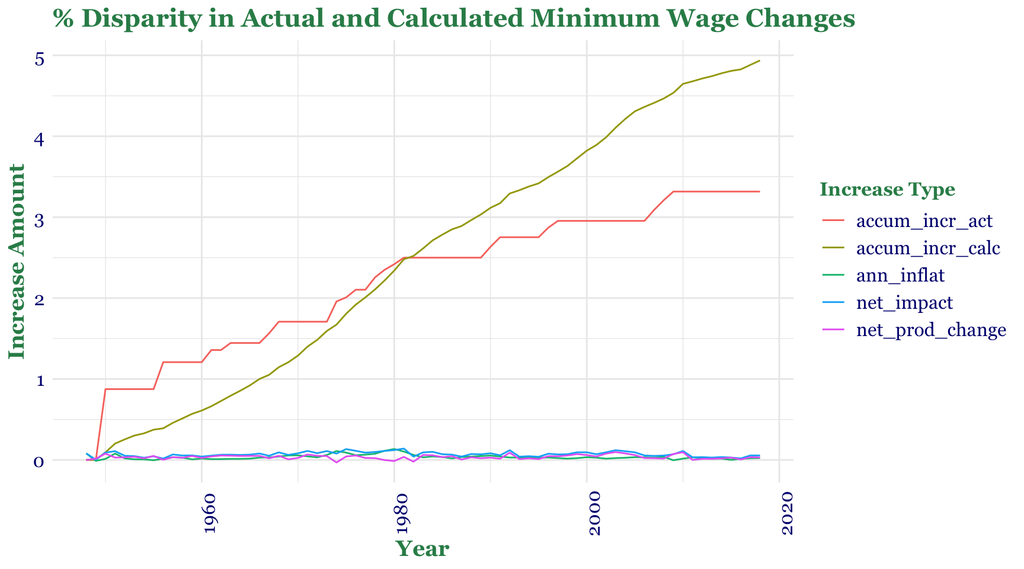

```r
ggplot() +
  geom_path(data = master_set_4, aes(x = Year, y = `Increase Amount`, color = `Increase Type`)) +
  labs(title = "% Disparity in Actual and Calculated Minimum Wage Changes") +
  wage_theme
```